# Kazanlak Kriging

Adela Sobotkova

29 March 2021 updated 30 March 2021

## Task 1: Kriging: Filling in the gaps

Now that you have generated a variogram from the locations with existing geochemical data, you can apply it to produce estimates at new locations. You can estimate new values at individual points or across the entire area of the valley, using kriging.

Kriging is the final part of geostatical estimation. This is the application of the variogram along with the sampled data points to produce estimates and uncertainties at new locations.

The computation of estimates and uncertainties, together with the assumption of a normal (Gaussian) response means you can compute any function of the estimates - for example the probability of a new location having highly fertile soil.

### Instructions

- The geochemical survey data `kaz_geo`, the dataframe with the missing values `kaz_geo_miss` and the variogram model `v_model`, were created in the previous exercise and should be in your environment.
- You will need to load the `gstat`, `sf`, and `raster` libraries.
- Complete the formula to indicate kriging with a spatial trend surface.
- Use the `kaz_geo_miss` as `newdata` locations.
- Plot the predicted organic matter from the returned object using ggplot() or spplot().

```r
# Load gstat, sf and raster library
library(_____)
library(_____)

# Reload kaz_geo, missing value dataframe and the v_model


# Set the trend formula and the new data
km <- krige(OM ~ ___ + ___, kaz_geo, newdata = kaz_geo_miss, model = v_model)
names(km)

# Plot the predicted values


# Compute the probability of highly fertile soil samples, and map
km$pFertile <- 1 - pnorm(7, mean = km$var1.pred, sd = sqrt(km$var1.var))
spplot(__________)
ggplot(_________)
```

### Solution

```
## [using universal kriging]
```

```
## [1] "var1.pred" "var1.var"  "geometry"
```

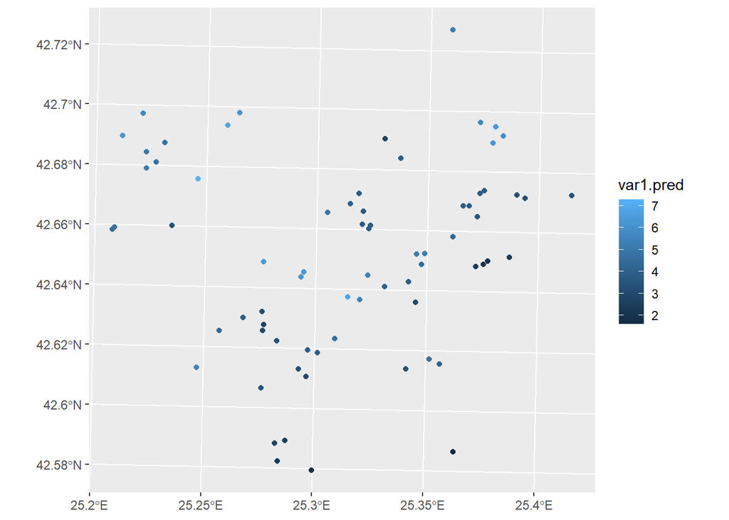

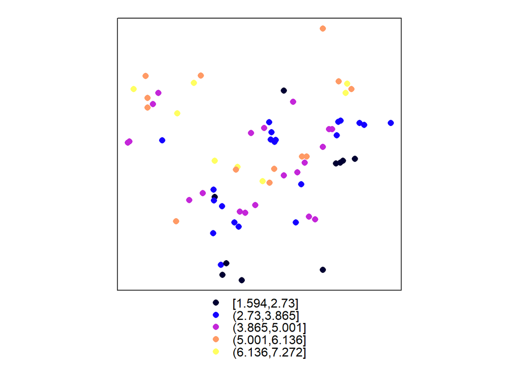

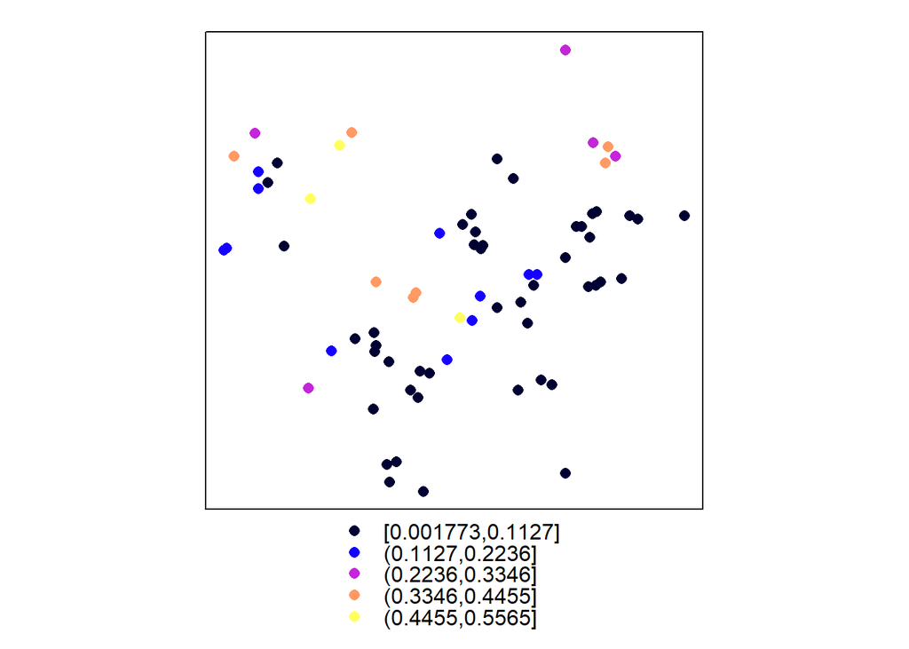

Well done on filling in the missing values using the previously generated variogram! Next you’ll see how to go from point predictions to gridded predictions.

## Task 2: Making a prediction grid

Past farmers used the fields around their villages. In order to evaluate their settlement choices, you need a map of soil probability that spans the valley rather than just village centroids. To do this, you are going to do some kriging using the `krige()` function over the study area. This requires a grid, or rather, a `SpatialPixels` object which will take a bit of data manipulation to create. You start by defining a grid, creating points on that grid, cropping to the study region, and then finally converting to `SpatialPixels`. On the way, you’ll meet some new functions.

`GridTopology()` defines a rectangular grid. It takes three vectors of length two as inputs. The first specifies the position of the bottom left corner of the grid. The second specifies the width and height of each rectangle in the grid, and the third specifies the number of rectangles in each direction.

To ensure that the grid and the study area have the same coordinates, some housekeeping is involved. `SpatialPoints()` converts the points to a coordinate reference system (CRS), or projection (different packages use different terminology for the same concept). The CRS is created by wrapping the study area in `projection()`, then in `CRS()`. This data manipulation is necessary to align the grid and the study area.

Now that you have that alignment, `crop()`, as the name suggests, crops the grid to the study area.

Finally, `SpatialPixels()` converts the raster cropped `gridpoints` to the equivalent `sp` object.

### Instructions

- Keep using the geochemical survey data `kaz_geo`, the missing value dataframe, `kaz_geo_miss`, the variogram,`vgm`, and the variogram model, `v_model` from previous exercises.
- Create the bounding box for the study area and assign to an object called `geo_bounds`.
- Use `st_bbox(geo_bounds)` to get the corners of the grid.
- Construct a rectangular grid over the region.
  - Call `GridTopology()`.
  - Round the position of the bottom left corner to the nearest integer and pass it as the first argument.
  - Assign the result to grid.
- Align the grid coordinate with the study area boundary coordinates.
  - Call `SpatialPoints()`.
  - Pass `grid` as the first argument.
  - Pass the coordinate reference system of the study area boundary to the `proj4string` argument.
  - Assign the result to `gridpoints`.
  - Plot this object to see your progress.
- Crop the grid points to the shape of the boundary object.
  - Call `crop()`.
  - Pass the grid points as the first argument.
  - Pass the study area boundary as the second argument.
  - Assign the result to `cropped_gridpoints`.
  - Plot this object to see your progress.
- Convert the cropped grid points to a `SpatialPixels` object.
  - Call `SpatialPixels()`.
  - Pass `cropped_gridpoints` as the only argument.
  - Assign the result to `spgrid`.
  - Plot this object to see your progress.

```r
# Create geo_bounds bounding box for kaz_geo
geo_bounds <- __________

# Plot the bounding box polygon and points


# Find the left bottom corner of the bounding box


# Define a 0.5km square grid over the polygon extent. The first parameter is the bottom left corner.
grid <- ___(___, c(500, 500), c(35, 40))

# Create points with the same coordinate system as the boundary box
gridpoints <- ___(___, proj4string = CRS(projection(___)))
plot(gridpoints)

# Crop out the points outside the boundary
cropped_gridpoints <- ___(gridpoints, ___)
plot(cropped_gridpoints)

# Convert to SpatialPixels
spgrid <- ___(cropped_gridpoints)
coordnames(spgrid) <- c("X", "Y")
plot(spgrid)
```

### Solution

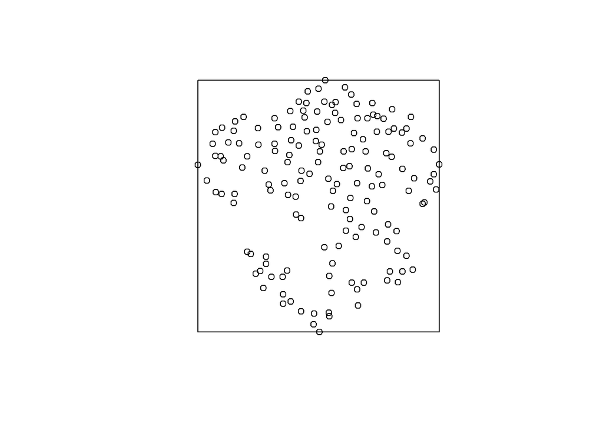

```
##      xmin      ymin      xmax      ymax
##  352042.5 4712740.7  369014.3 4730478.1
```

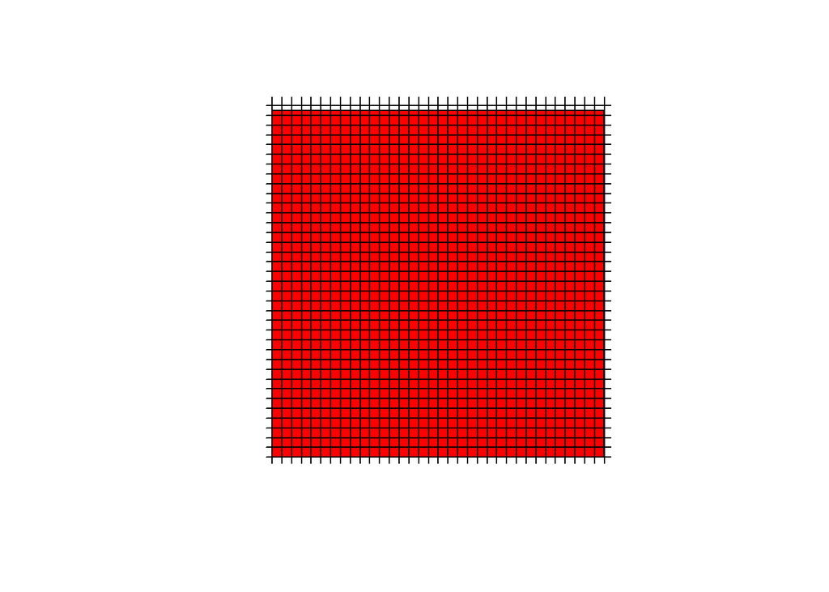

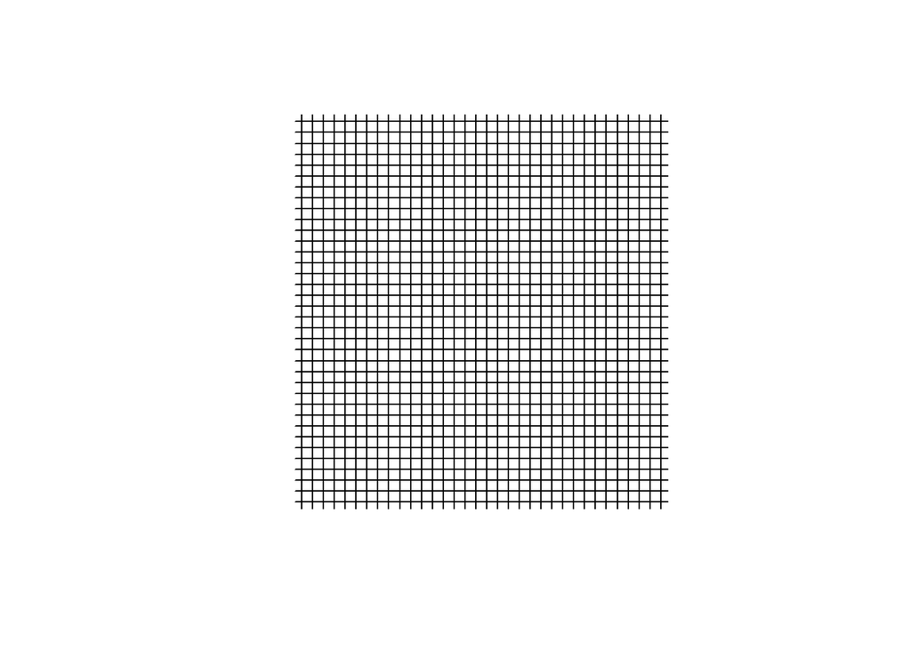

```
## [1] "SpatialPixels"
## attr(,"package")
## [1] "sp"
```

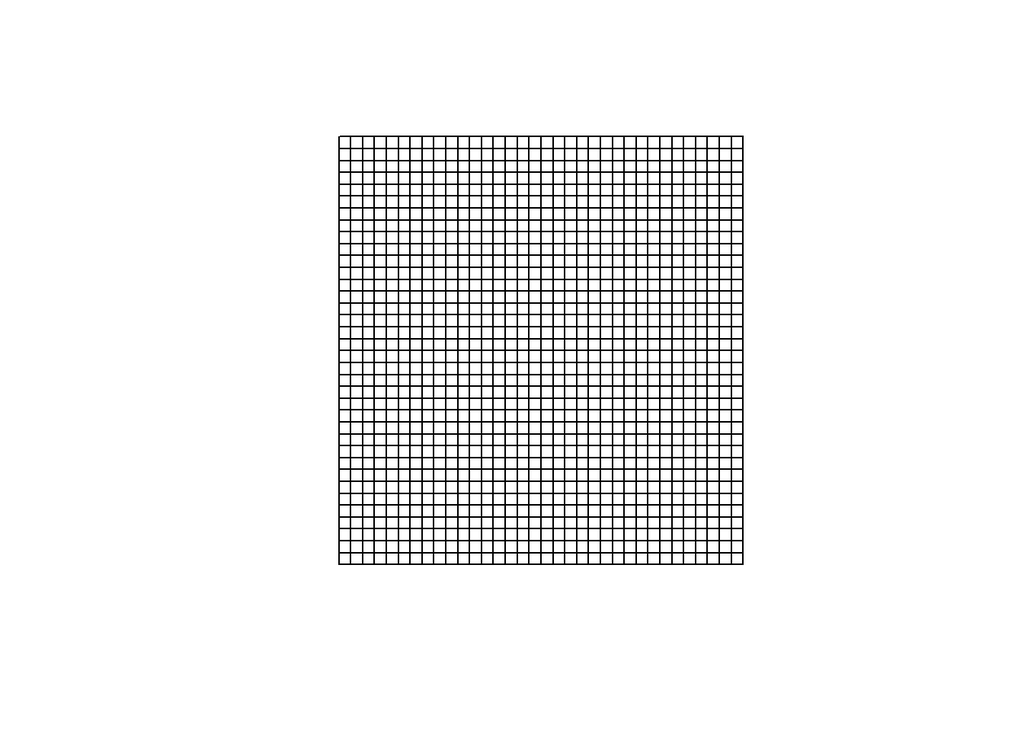

Good effort! Manipulating the data into the right form can be hard work. Now you have what you want, you can do some gridded kriging!

## Task 3: Gridded predictions

Constructing the grid is the hard part done. You can now compute `kriged` estimates over the grid using the variogram model from before (`v_model`) and the grid of `SpatialPixels`.

### Instructions

Use the spatial pixel grid of the region, `spgrid`, and the variogram model of OM, `v_model` from previous exercises.

- Ensure that the `spgrid` and `kaz_geo` objects have the same coordinate system definition with CRS() function.
- Use kriging to predict OM in each grid rectangle throughout the study area.
  - Call `krige()`.
  - The formula and input data are already specified.
  - Pass `spgrid` as the new data to predict.
  - Pass the variogram model to the model argument.
- Calculate the probability of fertile soil samples in each grid rectangle.
  - The mean of the predictions is the `var1.pred` element of `OM_grid`.
  - The variance of the predictions is the `var1.var` element of `OM_grid`. Take the square root to get the standard deviation.
- Plot the organic matter in each grid rectangle.
  - Call `spplot()`.
  - Pass the organic matter column to the `zcol` argument as a string

```r
# Adjust the kaz_geo CRS to be consistent with spgrid
crs(kaz_geo)
crs(spgrid)

# Do kriging predictions over the grid
OM_grid <- ___(OM ~ x + y, kaz_geo, newdata = ___, model = ___)

# Plot the soil-nutrient predictions in a grid


# Calculate the probability of organic matter exceeding 7
OM_grid$pFertile <- 1 - pnorm(7, mean = OM_grid$___, sd = ___(OM_grid$___))

# Map the probability of soils OM exceeding 7
spplot(OM_grid, zcol = "___")

# Plot soil-nutrient content estimates with a color ramp
```

### Solution

```
## CRS arguments:
##  +proj=utm +zone=35 +datum=WGS84 +units=m +no_defs
```

```
## CRS arguments:
##  +proj=utm +zone=35 +datum=WGS84 +units=m +no_defs
```

```
## [using universal kriging]
```

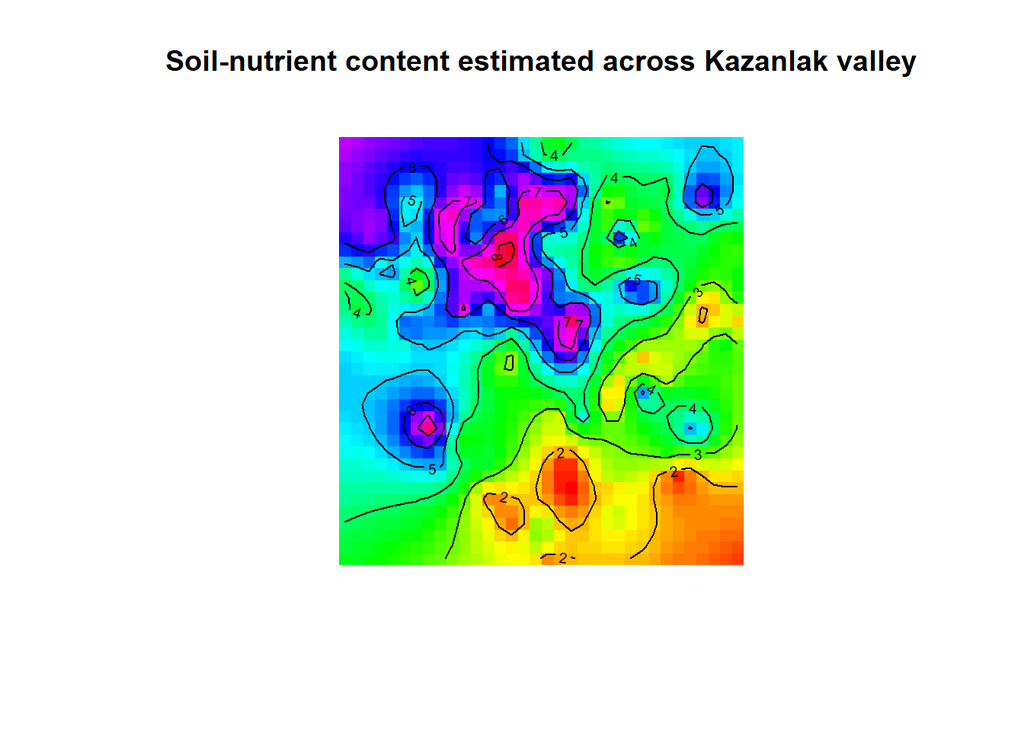

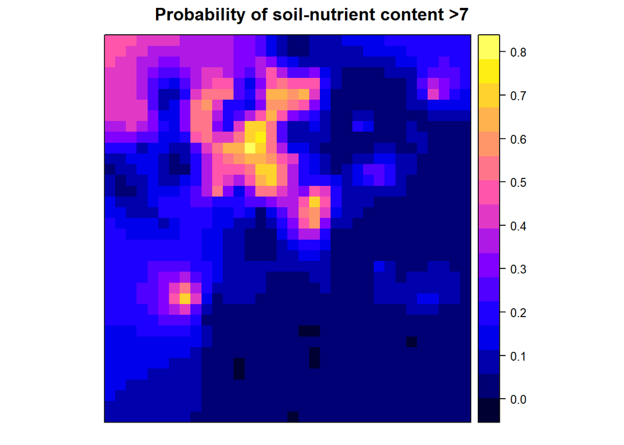

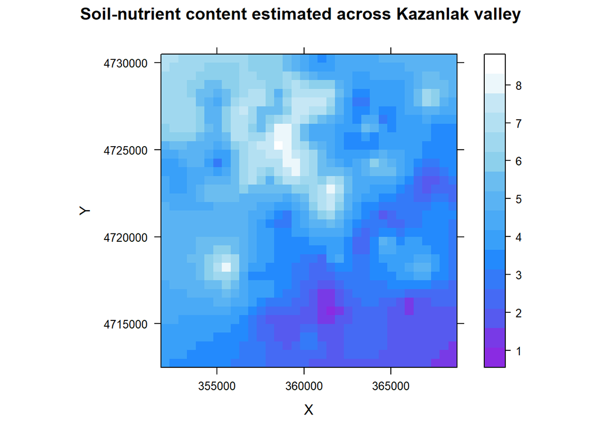

The regions with fertile soil samples are much clearer than in the maps of points that you saw at the start of the chapter.

## Task 4: Auto-kriging at point locations

The `autoKrige()` function in the `automap` package computes binned variograms, fits models, does model selection, and performs kriging by making multiple calls to the `gstat` functions you used previously. It can be a great time-saver but you should always check the results carefully.

We will apply it here to get predictions at the ancient village locations so we can compare with manual results.

`autoKrige()` can try several variogram model types. In the example, you’ll use a Matern variogram model, which is commonly used in soil and forestry analyses. You can see a complete list of available models by calling `vgm()` with no arguments.

### Instructions

- Activate the `automap` package
- Call `autoKrige()` to automatically run a kriging model.
  - Set the formula for modeling organic matter versus the position, as before.
  - The `input_data` is the non-missing data from the survey.
  - The `new_data` is the missing data from the survey.
  - Set the `model` to `"Mat"`. (Note the capital M)
  - Assign the result to `OM_auto`.
- Call `plot()` on `OM_auto` to see the results.

```r
# Ensure all the necessary objects exist


# Kriging with linear trend, predicting over the missing points
OM_auto <- autoKrige(
  ___ ~ ___ + ___,
  input_data = ___,
  new_data = ___,
  model = "___"
)

# Plot the variogram, predictions, and standard error
___
```

### Solution

```
## Simple feature collection with 72 features and 4 fields
## geometry type:  POINT
## dimension:      XY
## bbox:           xmin: 353104 ymin: 4715518 xmax: 370091.5 ymax: 4731819
## projected CRS:  WGS 84 / UTM zone 35N
## First 10 features:
##      ID        X       Y OM                 geometry
## 1  3057 359988.8 4719268 NA POINT (359988.8 4719268)
## 2  4097 363961.0 4719265 NA   POINT (363961 4719265)
## 3  2031 364808.1 4719634 NA POINT (364808.1 4719634)
## 4  2032 365202.3 4719448 NA POINT (365202.3 4719448)
## 5  2019 361326.9 4720388 NA POINT (361326.9 4720388)
## 6  1015 359190.9 4720314 NA POINT (359190.9 4720314)
## 7  1008 358711.5 4723245 NA POINT (358711.5 4723245)
## 8  1006 357063.9 4720699 NA POINT (357063.9 4720699)
## 9  3053 359106.8 4716524 NA POINT (359106.8 4716524)
## 10 3059 359476.3 4716620 NA POINT (359476.3 4716620)
```

```
## Simple feature collection with 155 features and 28 fields
## geometry type:  POINT
## dimension:      XY
## bbox:           xmin: 352042.5 ymin: 4712741 xmax: 369014.3 ymax: 4730478
## projected CRS:  WGS 84 / UTM zone 35N
## # A tibble: 155 x 29
##       ID Priority    pH Salinity Notes    OM Carbonate Colour Land_use Texture
##  * <dbl>    <dbl> <dbl>    <dbl> <chr> <dbl>     <dbl> <chr>  <chr>    <chr>
##  1     0        0     0        0 SE     1.2          0 10YR4~ Disturb~ Chalky~
##  2     1        0     0        0 SE     3            0 10YR3~ Terrace~ Sandy ~
##  3     2        0     0        0 SW     2.25         0 10YR3~ Pasture  Sandy ~
##  4     3        0     0        0 SW     4            0 10YR3~ Disturb~ Light ~
##  5     4        0     0        0 <NA>   1.5          0 10YR3~ Pasture  Sandy ~
##  6     5        0     0        0 E      0.8          0 10YR4~ Pine fo~ Chalky~
##  7     7        0     0        0 NW     2.25         0 10YR3~ Rotary ~ Loam
##  8     6        0     0        0 <NA>   3            0 10YR3~ Blueber~ Clay l~
##  9     8        0     0        0 NW     1.5          0 10YR3~ Oak for~ Sandy ~
## 10    11        0     0        0 NE     0.8          0 10YR4~ Ploughe~ Clay l~
## # ... with 145 more rows, and 19 more variables: Photo <chr>, Day <dbl>,
## #   Text_desc <chr>, Coarse_siz <dbl>, Coarse_per <dbl>, Coarse_rou <dbl>,
## #   Text_silt <dbl>, Text_sand <dbl>, Text_clay <dbl>, Sum <dbl>, Struct <dbl>,
## #   Perm_rock <dbl>, k_factor <dbl>, OM_muns <dbl>, Density <dbl>,
## #   TARGET_FID <dbl>, geometry <POINT [m]>, X <dbl>, Y <dbl>
```

```
## [using universal kriging]
```

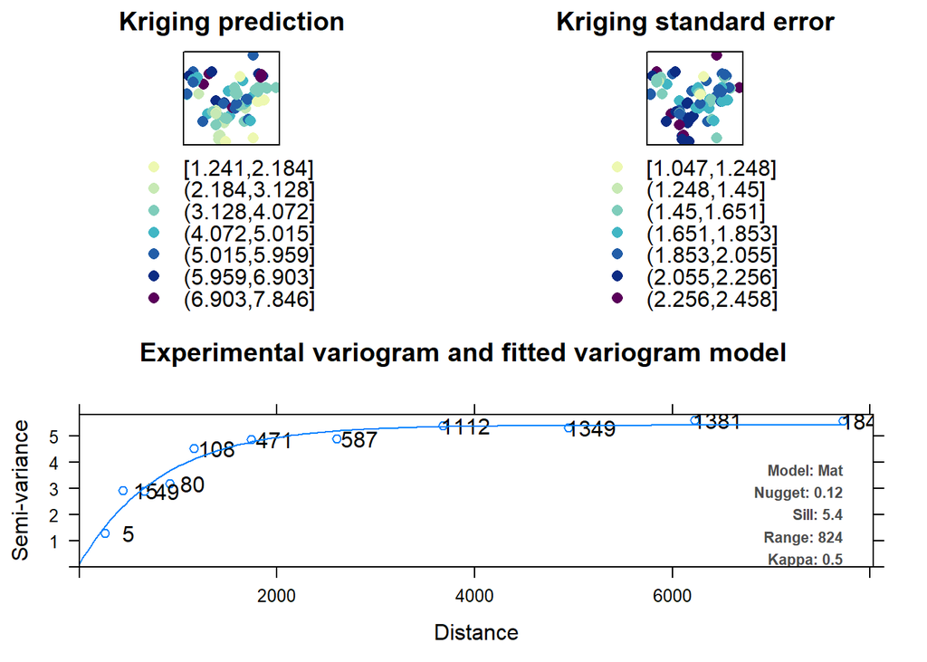

Beautiful charts. Notice alignment between the Kriging predictions and the plot created in Task 1: The cluster in the southeast is predicted to be infertile, while there are clusters in the northwest, northeast and center that are estimated to be highly fertile. Pretty neat!

## Task 5: Auto-kriging over a grid

You can also use `autoKrige()` over the `spgrid` grid from the earlier exercise. This brings together all the concepts that you’ve learned today. That is, kriging is great for predicting missing data, plotting things on a grid is much clearer than plotting individual points, and automatic kriging is less hassle than manual kriging.

### Instructions

The geochem survey data, `kaz_geo`, the missing value dataframe, `kaz_geo_miss`, the spatial pixel grid of the region, `spgrid`, the manual kriging grid model, `OM_grid`, and the variogram model of OM, `v_model` are in your environment or defined above.

- Automatically fit a kriging model.
  - Call `autoKrige()`.
  - The first argument is the same formula you have used throughout the exercise.
  - The `input_data` argument contains the geochemical survey data.
  - The `new_data` argument is the grid of prediction locations.
  - Assign the result to `OM_auto_grid`.
- To remind yourself of the manual kriging predictions, plot `OM_grid`.
- Plot `OM_auto_grid`. *Do the predictions look similar or different?*
- To compare the manual and automated variogram models, print `v_model` the `var_model` element of `OM_auto_grid`

```r
# Load the library

# Auto-run the kriging
OM_auto_grid <- ___(___, input_data = ___, new_data = ___)

# Remember predictions from manual kriging
plot(OM_grid)

# Plot predictions and variogram fit
plot(OM_auto_grid)

# Compare the variogram model to the earlier one
v_model
OM_auto_grid$___
```

### Solution

```
## [using universal kriging]
```

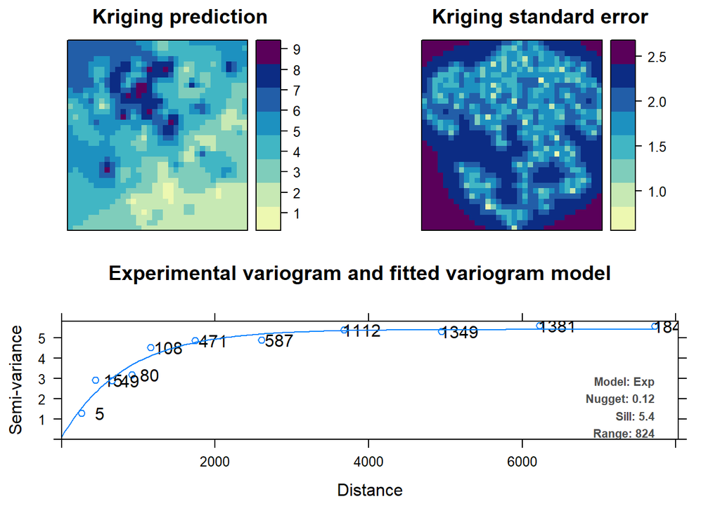

```
## [1] "krige_output" "exp_var"      "var_model"    "sserr"
```

```
##   model    psill    range kappa
## 1   Nug 1.595013    0.000   0.0
## 2   Ste 3.937716 1643.216   0.5
```

```
##   model     psill    range
## 1   Nug 0.1165306   0.0000
## 2   Exp 5.2926661 823.5611
```

Lovely result! The scale in inverse (dark areas show high organic-matter content) but otherwise the result is practically identical to the plot you created manually in task 3 above. Automated kriging gives you a lot of modeling power for not much effort.